# Introducción R

Vamos a empezar a practicar R con un dataset sobre los fubolistas de FIFA 2021.

Nos vamos a descargar los datos de FIFA de aquí: https://www.kaggle.com/stefanoleone992/fifa-21-complete-player-dataset

## Carga de datos

En R podemos importar ficheros CSV como un dataframe:

```r
#Importamos el CSV:
df_fifa<-read.csv('datos/players_21.csv', stringsAsFactors = F)
# Nos quedamos solo con ciertas columnas del dataset
df_fifa<-df_fifa[,c('long_name',"dob",'height_cm','weight_kg','nationality','league_rank','overall','value_eur')]
```

Vamos a ver las características del dataframe que hemos importado:

```r
summary(df_fifa)
```

```
  long_name             dob              height_cm       weight_kg      nationality         league_rank
 Length:18944       Length:18944       Min.   :155.0   Min.   : 50.00   Length:18944       Min.   :1.000
 Class :character   Class :character   1st Qu.:176.0   1st Qu.: 70.00   Class :character   1st Qu.:1.000
 Mode  :character   Mode  :character   Median :181.0   Median : 75.00   Mode  :character   Median :1.000
                                       Mean   :181.2   Mean   : 75.02                      Mean   :1.357
                                       3rd Qu.:186.0   3rd Qu.: 80.00                      3rd Qu.:1.000
                                       Max.   :206.0   Max.   :110.00                      Max.   :4.000
                                                                                           NA's   :225
    overall        value_eur
 Min.   :47.00   Min.   :        0
 1st Qu.:61.00   1st Qu.:   300000
 Median :66.00   Median :   650000
 Mean   :65.68   Mean   :  2224813
 3rd Qu.:70.00   3rd Qu.:  1800000
 Max.   :93.00   Max.   :105500000
```

Podemos ver las primeras filas con:

[output not shown]

O las últimas con tail():

```r
tail(df_fifa)
```

[output not shown]

También podemos ver las filas o columnas que queramos:

```r
df_fifa[c(1,2,5,7,10),c('long_name','nationality','league_rank')]
```

|  | long_name | nationality | league_rank |
| --- | --- | --- | --- |
| 1 | Lionel Andrés Messi Cuccittini | Argentina | 1 |
| 2 | Cristiano Ronaldo dos Santos Aveiro | Portugal | 1 |
| 5 | Neymar da Silva Santos Júnior | Brazil | 1 |
| 7 | Kylian Mbappé Lottin | France | 1 |
| 10 | Alisson Ramsés Becker | Brazil | 1 |

## Transformación de datos:

Vamos a cambiar el formato de algunas columnas:

```r
df_fifa$dob<-as.Date(df_fifa$dob)
df_fifa$nationality<-factor(df_fifa$nationality)
```

Al cambiar la nacionalidad a factor() podemos ver con el `summary()` cuales son las nacionalidades más populales, y también podemos ver como se distribuyen las fechas de nacimiento:

```r
summary(df_fifa)
```

[output not shown]

Creamos dos nuevas columnas una con el nombre del mes de nacimiento y otra con el número del mes. Para ello usamos la función `month` disponible en la librería `lubridate`. Para instalar esta librería puedes ejecutar el comando `install.packages('lubridate')`:

```r
library(lubridate)
df_fifa$month_name<-month(df_fifa$dob, label=TRUE)
df_fifa$month_num<-month(df_fifa$dob, label=F)
```

Vemos el resultado:

```r
summary(df_fifa)
```

```
  long_name              dob               height_cm       weight_kg         nationality     league_rank
 Length:18944       Min.   :1967-02-26   Min.   :155.0   Min.   : 50.00   England  : 1685   Min.   :1.000
 Class :character   1st Qu.:1991-06-16   1st Qu.:176.0   1st Qu.: 70.00   Germany  : 1189   1st Qu.:1.000
 Mode  :character   Median :1995-03-30   Median :181.0   Median : 75.00   Spain    : 1072   Median :1.000
                    Mean   :1994-10-18   Mean   :181.2   Mean   : 75.02   France   :  984   Mean   :1.357
                    3rd Qu.:1998-07-25   3rd Qu.:186.0   3rd Qu.: 80.00   Argentina:  936   3rd Qu.:1.000
                    Max.   :2003-09-27   Max.   :206.0   Max.   :110.00   Brazil   :  887   Max.   :4.000
                                                                          (Other)  :12191   NA's   :225
    overall        value_eur           month_name     month_num
 Min.   :47.00   Min.   :        0   feb    :2204   Min.   : 1.000
 1st Qu.:61.00   1st Qu.:   300000   ene    :2103   1st Qu.: 3.000
 Median :66.00   Median :   650000   mar    :1864   Median : 5.000
 Mean   :65.68   Mean   :  2224813   abr    :1712   Mean   : 5.835
 3rd Qu.:70.00   3rd Qu.:  1800000   may    :1630   3rd Qu.: 9.000
 Max.   :93.00   Max.   :105500000   jul    :1470   Max.   :12.000
                                     (Other):7961
```

## Analisis exploratorio

Vamos a empezar haciendo diferentes correlaciones entre las variables numéricas:

```r
(cor_fifa<-cor(df_fifa[,c(3,4,6,7,8,10)],use='pairwise.complete.obs'))
```

```
               height_cm   weight_kg league_rank     overall    value_eur    month_num
height_cm    1.000000000  0.77299408  0.06123296  0.03157934  0.004123977 -0.006824131
weight_kg    0.772994082  1.00000000  0.00594747  0.14624165  0.044709950 -0.012770668
league_rank  0.061232959  0.00594747  1.00000000 -0.21709015 -0.144324687  0.057541136
overall      0.031579342  0.14624165 -0.21709015  1.00000000  0.630085121 -0.010710418
value_eur    0.004123977  0.04470995 -0.14432469  0.63008512  1.000000000  0.003275760
month_num   -0.006824131 -0.01277067  0.05754114 -0.01071042  0.003275760  1.000000000
```

Pero me gustaria verlo de una forma mas grafica:

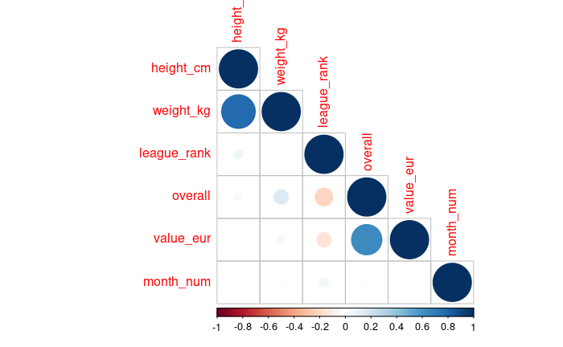

```r
library(corrplot)
corrplot(cor_fifa, type='lower')
```

Buscamos el futbolista con mayor peso:

|  | long_name | dob | height_cm | weight_kg | nationality | league_rank | overall | value_eur | month_name | month_num |
| --- | --- | --- | --- | --- | --- | --- | --- | --- | --- | --- |
| 10346 | Adebayo Akinfenwa | 1982-05-10 | 178 | 110 | England | 2 | 65 | 190000 | may | 5 |

O el más bajo:

|  | long_name | dob | height_cm | weight_kg | nationality | league_rank | overall | value_eur | month_name | month_num |
| --- | --- | --- | --- | --- | --- | --- | --- | --- | --- | --- |
| 12538 | 中川 寛斗 | 1994-11-03 | 155 | 57 | Japan | 1 | 63 | 475000 | nov | 11 |

Buscamos los paises con más futbolistas.

```r
num_futbolistas <- sort(table(df_fifa[,c('nationality')]),decreasing=T)
num_futbolistas[1:10]
```

```
      England       Germany         Spain        France     Argentina        Brazil         Japan
         1685          1189          1072           984           936           887           489
  Netherlands         Italy United States
          432           421           378
```

## Comparación fecha nacimiento

Vamos a ver el mes de nacimiento de los futbolistas españoles:

```r
tbl_spain<-table(df_fifa[df_fifa$nationality=='Spain' ,"month_name"])
tbl_spain
```

```
ene feb mar abr may jun jul ago sep oct nov dic
137 122 113  94  99  84  79  78  81  66  61  58
```

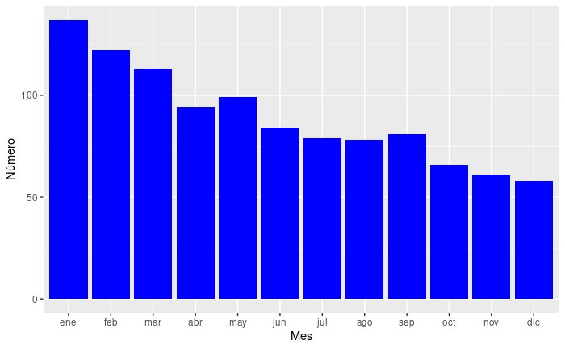

```r
library(ggplot2)
df_tbl_spain <- data.frame(tbl_spain)
ggplot(df_tbl_spain, aes(x=Var1,y=Freq))+geom_col(fill='blue')+xlab('Mes')+ylab('Número')
```

Podemos hacer lo mismo con Alemania

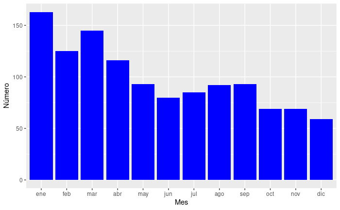

```r
df_tbl_germany <- data.frame(
  table(df_fifa[df_fifa$nationality=='Germany',"month_name"]))
ggplot(df_tbl_germany, aes(x=Var1,y=Freq))+geom_col(fill='blue')+xlab('Mes')+ylab('Número')
```

Y con inglaterra:

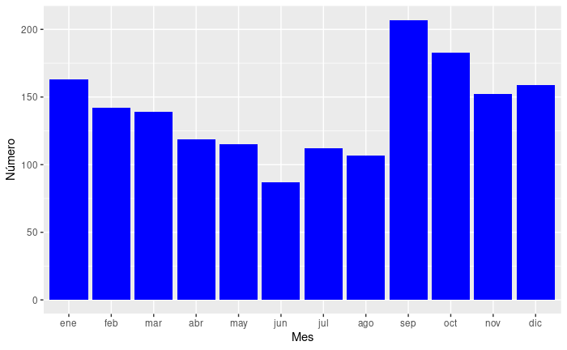

```r
df_tbl_england <- data.frame(
  table(df_fifa[df_fifa$nationality=='England',"month_name"]))
ggplot(df_tbl_england, aes(x=Var1,y=Freq))+geom_col(fill='blue')+xlab('Mes')+ylab('Número')
```

¿Esta diferencia que vemos es estadísticamente significativa o puede haber ocurrido por pura casualidad? Para responder a esta pregunta tenemos los tests estadísticos. Podemos suponer que en condiciones “ideales” la probabilidad de nacer en cada mes es la misma, es decir, deberíamos esperar que todos los futbolistas se distribuyeran de forma uniforme. Esto lo podemos verificar con el test chi.sq:

```r
chisq.test(tbl_spain)
```

```
    Chi-squared test for given probabilities

data:  tbl_spain
X-squared = 74.739, df = 11, p-value = 1.521e-11
```

Como el pvalor es tan bajo podemos descartar la hipótesis nula (todos los meses tienen la misma probabilidad de nacimiento) y aceptar la hipótesis alternativa (hay meses que tienen una mayor probabilidad de nacimientos que otros).

## Distribución de nacimientos población total

Vamos a comprobar la distribución de nacimientos de fubolistas con los de la población en general. Para ello nos ayudaremos de los datos que publica la ONU y de una función de ayuda que hemos escrito y se encuentra en el fichero `utils_nacimientos.R`:

```r
source('utils_nacimientos.R')
```

Vamos ejecutarla la función de prueba:

```r
get_nacimientos_para_pais('Spain')
```

```
   ene    feb    mar    abr    may    jun    jul    ago    sep    oct    nov    dic
706820 647515 718727 703995 741266 693060 729822 710382 722521 718922 678790 697044
```

Creamos una función que nos junte la salida de la tabla con los futbolistas y la población general:

```r
get_table_pais<-function(pais) rbind(
 fifa=table(df_fifa[df_fifa$nationality==pais,"month_name"]),
 normal=get_nacimientos_para_pais('Spain')
 )
```

Podemos ver la proproción de nacimiento en cada mes. Hay que tener en cuenta que no todos los meses tienen los mismos días, por eso hay meses donde hay menos nacimientos

```r
prp_spain<-prop.table(get_table_pais('Spain'),margin = 1)
prp_spain
```

```
              ene        feb        mar        abr        may        jun        jul        ago        sep
fifa   0.12779851 0.11380597 0.10541045 0.08768657 0.09235075 0.07835821 0.07369403 0.07276119 0.07555970
normal 0.08346102 0.07645831 0.08486699 0.08312744 0.08752839 0.08183624 0.08617708 0.08388162 0.08531498
              oct        nov        dic
fifa   0.06156716 0.05690299 0.05410448
normal 0.08489002 0.08015125 0.08230667
```

Podemos “normalizar” y ver la probabilidad por día

```r
prp_norm_spain<-prp_spain/c(31,28,31,30,31,30,31,31,30,31,30,31)
prp_norm_spain
```

```
             ene        feb         mar         abr         may         jun         jul         ago
[1,] 0.004122532 0.00367116 0.003400337 0.002828599 0.003078358 0.002611940 0.002377227 0.002347135
[2,] 0.002980751 0.00254861 0.002828900 0.002681530 0.002823496 0.002639879 0.003077753 0.002796054
             sep         oct         nov         dic
[1,] 0.002437410 0.001986038 0.001896766 0.001803483
[2,] 0.002843833 0.002738388 0.002585524 0.002655054
```

Esto podemos pintarlo en un gráfico:

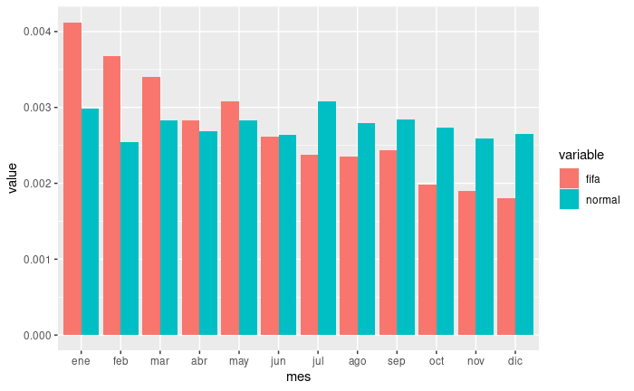

```r
df_prp_norm_spain<-as.data.frame(t(prp_norm_spain))
colnames(df_prp_norm_spain)<-c('fifa','normal')
df_prp_norm_spain$mes <- rownames(df_prp_norm_spain)
df_prp_norm_spain$mes <-factor(df_prp_norm_spain$mes, levels = c('ene','feb','mar','abr','may','jun','jul','ago','sep','oct','nov','dic'))

library(reshape2)
df<-melt(df_prp_norm_spain)
ggplot(df,aes(x=mes,y=value,fill=variable))+geom_col(position='dodge')
```